# Analysis of PTSD Model Simulations

Andrea Stocco

2/7/2021

# Model and Simulations

This is an analysis of the PTSD model “complete” simulations (“Simulation 3”).

## Trajectories to simulate

One of the goals of the model is to simulate the recovery trajectories in PTSD. The classic distinction is between four different trajectories, Resilient, Recovery, Chronic, and Delayed. These trajectories can be stylized as such

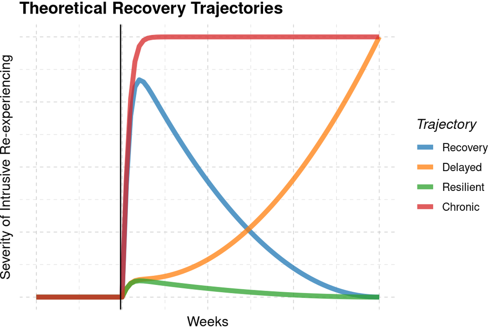

```r
time <- -20:60

resilient <- rep(0, length(time))
chronic <- tanh(time/2)
delayed <- time**2 / max(time**2)
#recovery <- chronic - delayed
recovery <- chronic + ((60 - time)**2 / max(time**2)-1)
#recovery <- recovery/max(recovery)

## Add a little bump to resilient

resilient <- resilient + recovery * 0.075
delayed <- delayed + recovery * 0.075

resilient[time <= 0] <- 0
chronic[time <= 0] <- 0
delayed[time <= 0] <- 0
recovery[time <= 0] <- 0

wideal <- tibble(Weeks = time,
                Chronic = chronic,
                Delayed = delayed,
                Recovery = recovery,
                Resilient = resilient)

ideal <- wideal %>%
  pivot_longer(cols=c("Chronic", "Delayed", "Resilient", "Recovery"),
               values_to = "CTraumatic",
               names_to = "Trajectory")

ideal$Trajectory <- factor(ideal$Trajectory,
                           levels = c("Recovery", "Delayed", "Resilient",  "Chronic"))

ggplot(ideal,
       aes(x=Weeks,
           y=CTraumatic,
           col=Trajectory,
           fill=Trajectory)) +
  #geom_smooth(method="loess", span=0.2) +
  geom_line(size=2, alpha=0.75) +
  ggtitle("Theoretical Recovery Trajectories") +
  ylab("Severity of Intrusive Re-experiencing") +
  geom_vline(data=tibble(),
             aes(xintercept=-0.35)) +
  scale_color_d3() +
  theme_pander()  +
  theme(axis.text.y = element_blank(),
        axis.ticks.y = element_blank(),
        axis.text.x = element_blank(),
        axis.ticks.x = element_blank())
```

## Underlying memory model

The underlying memory model is John Anderson’s ACT-R.

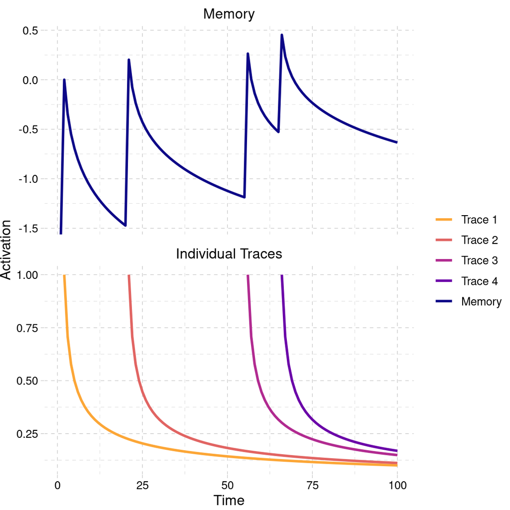

```r
# Simulate ACT-R

decay <- function(time, t0=0, rate=.5) {
    if (time <= t0) {
      NA
    } else {
      (time - t0)**(-rate)
    }
}

vdecay <- Vectorize(decay)

time <- seq(1, 100, 1)

t1 = vdecay(time, t0=1)
t2 = vdecay(time, t0=20)
t3 = vdecay(time, t0=55)
t4 = vdecay(time, t0=65)


df <-data.frame(Time=time,
           trace1 = vdecay(time, t0=1),
           trace2 = vdecay(time, t0=20),
           trace3 = vdecay(time, t0=55),
           trace4 = vdecay(time, t0=65))


ldf <- df %>%
  # mutate(Total = if_else(is.na(trace1), 0, trace1) +
  #          if_else(is.na(trace2), 0, trace2) +
  #          if_else(is.na(trace3), 0, trace3) +
  #          if_else(is.na(trace4), 0, trace4))  %>%
  pivot_longer(cols = c("trace1", "trace2", "trace3", "trace4"),
               names_to = "Trace", values_to="Activation")

ldf$Trace <- fct_recode(ldf$Trace,
                        "Trace 1" = "trace1",
                        "Trace 2" = "trace2",
                        "Trace 3" = "trace3",
                        "Trace 4" = "trace4")

ldf <- ldf %>%
  add_column(Source="Individual Traces")

t1[is.na(t1)] <-0
t2[is.na(t2)] <-0
t3[is.na(t3)] <-0
t4[is.na(t4)] <-0
total <- log(t1+t2+t3+t4)

totaldf <- tibble(Time=time,
                  Activation = total,
                  Trace = "Memory",
                  Source="Memory")

ldf <- rbind(ldf, totaldf)

ldf$Source <- factor(ldf$Source, levels = c("Memory", "Individual Traces"))

ggplot(ldf,
       aes(x=Time, y=Activation, col=Trace)) +
  geom_line(size=1,
            alpha=1) +
            #linetype="dashed") +
  # stat_summary(geom="line", fun = sum,
  #              col="black",
  #              alpha=0.5,
  #              position = position_dodge()) +
  # #scale_y_log10() +
  facet_wrap(~ Source, ncol=1,
             scales = "free_y") +
  #ylim(0, 1.6) +
  #ylab(expression(paste("Availability of Memory ", italic(m))))+
  ylab("Activation") +
  scale_color_viridis("", option="plasma", discrete=T, end = .8, direction=-1) +
  theme_pander()
```

### Neurological interpretation

```r
brain_model <- tibble(
  region = c("parahippocampal", "entorhinal", "medial orbitofrontal",
             "superior frontal", "paracentral", "precuneus"),
  component = c("LTM", "Emotional Intensity", "Retrieval Control",
                "Context", "Context", "Context")
)

#brain_model$component <- as_factor(brain_model$component)

# brain_model %>%
#  group_by(component) %>%
  # ggplot(aes(fill = component)) +
  # geom_brain(atlas = dk,
  #            col="white",
  #            show.legend = T
  #            ) +
  # labs(fill="Model\nComponent") +
  # #scale_fill_lancet(na.value="lightgrey") +
  # scale_fill_manual(na.value="lightgrey",
  #                    values=c("dodgerblue2", "goldenrod1", "firebrick3",
  #                             "lightskyblue3", "lightskyblue3", "lightskyblue3"),
  #                    breaks = brain_model$component) +
  # coord_sf(xlim = c(750, 1050)) +
  # theme_brain2(text.family = "sans",
  #              text.colour="black")
```

## Event Distribution

The distribution of Gamma events is this:

- Frequency: 2.1, 175 (shape, scale)
- Rumination, 6, 100

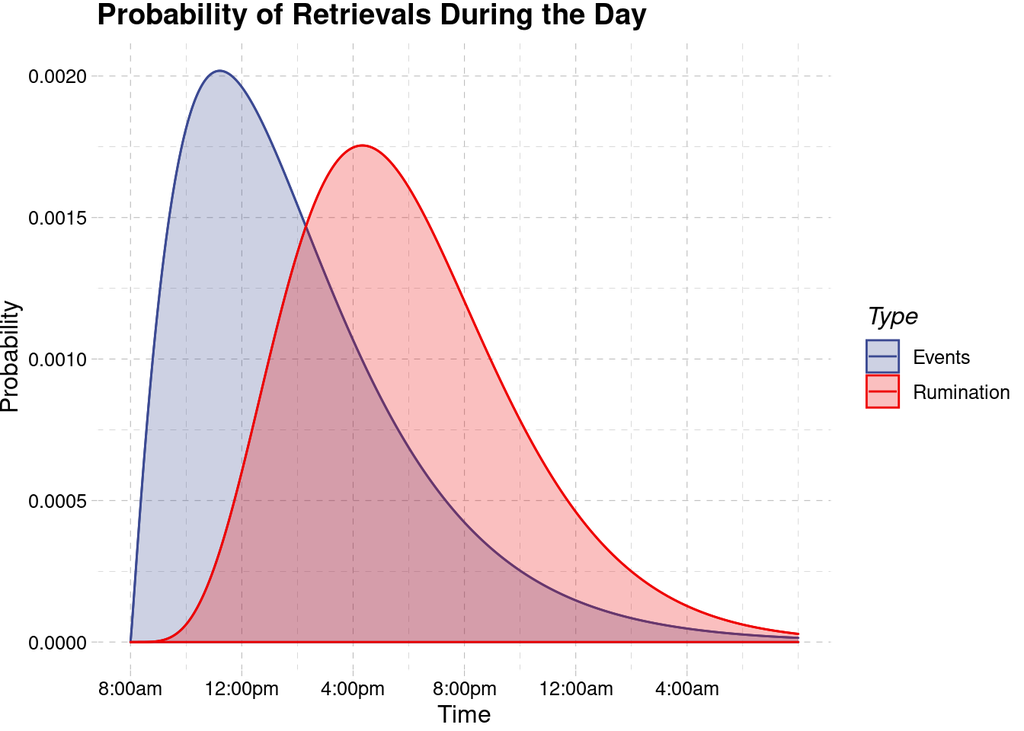

```r
t <- 0:(24*60)
E <- dgamma(t, shape=2.1, rate=1/175)
R <- dgamma(t, shape=6, rate=1/100)

dists <- data.frame(Time=t, Events = E, Rumination = R) %>%
  pivot_longer(names_to = "Type",
               values_to = "Probability",
               cols=c("Events", "Rumination"))

ggplot(dists, aes(x=Time, y=Probability, col=Type, fill=Type)) +
  geom_line() +
  geom_ribbon(data=dists, aes(x=Time, ymax=Probability, ymin=0), alpha=0.25) +
  scale_x_continuous(breaks=60*c(0, 4, 8, 12, 16, 20),
                     limits=c(0, 24*60),
                     labels=c("8:00am",
                              "12:00pm",
                              "4:00pm",
                              "8:00pm",
                              "12:00am",
                              "4:00am")) +
  scale_color_aaas() +
  scale_fill_aaas() +
  ggtitle("Probability of Retrievals During the Day") +
  theme_pander()
```

# Load and Transform the Data

First, we are going to load the “aggregated” version of the simulations, with the events already aggregated by day.

```r
CREATE_AGGREGAGATED = F

if (CREATE_AGGREGAGATED) {
  d <- read_csv("../simulations/simulations3.csv")
  #d <- read_csv("simulations3.csv", col_types = cols())
  d <- d %>%
    mutate(Day = floor(Time / (60*60*24)) - 100,
           Hour = floor((d$Time / 3600) %% 24),
           RuminationFrequency=as_factor(RuminationFrequency))
  names(d)[18] <- "W"

  d <- d %>%
    dplyr::select(Run, Day, PTEV, Gamma, PTES, W,
                  NumAttributes, RuminationFrequency,
                  MemoryEntropy, ChunkSimilarity, Traumatic, ChunkV) %>%
    filter(Day > -20)

  a <- d  %>%
    group_by(Run, Day, PTEV, PTES, Gamma,
             NumAttributes, RuminationFrequency, W) %>%
    summarise(MemoryEntropy = mean(MemoryEntropy),
              ChunkSimilarity = mean(ChunkSimilarity),
              PTraumatic = mean(Traumatic),
              CTraumatic = sum(Traumatic),
              ChunkV = mean(ChunkV))

  write_csv(x=a, file = "../simulations/simulations3_aggregated2.csv")
}

a <- read_csv(gzfile("../simulations/simulations3_aggregated2.csv.gz"),
              col_types = cols())
```

Then, we are going to rename the simulation variables to make them consistent with the names used in published papers:

```r
a <- a %>%
  rename(I = PTEV) %>%
  rename(gamma = Gamma) %>%
  rename(A = NumAttributes) %>%
  rename(C = PTES) %>%
  rename(R = RuminationFrequency)
```

## Recovery Trajectories

To identify a recovery trajectory, we need to first define a classification function. Here, we are going to use the following algorithm:

First the model calculates three average values:

1. The mean probability *P(baseline)* of retrieving intrusive memories in the 10 days preceding the PTE, or *baseline* period. By definition, this is always zero.
2. The mean probability *P(acute)* of retrieving intrusive memories in the 10 days following the PTE, or during the *acute* period.
3. The mean probability *P(chronic)* of retrieving intrusive memories in the last ten days of the second month after the PTE (i.e, days 51-60), or the *chronic* period.

Then, the model calculates two statistical tests:

1. A *t*-test between the baseline and acute period, or *acute test*; and
2. A *t*-test between the acute-period and the chronic period, or *chronic test*.

And finally we apply the following decision tree:

1. If the acute test is significant at p < .05 (Pacute > Pbaseline), then

   1.1. If the chronic test is also significant at *p* < .05, and Pchronic > Pacute, we classify the trajectory as **Delayed**.

   1.2. If the chronic test is significant at *p* < .05 but *P(chronic)* < *P(acute)*, then we classify the trajectory as **Recovery**;

   1.3. If the chronic test is non-significant, then *P(chronic)* ~ *P(acute)* , and we classify the trajectory as **Chronic**.
2. If, instead, the acute test is not significant and *P(acute)* ~ *P(baseline)*, then:

   2.1. If the chronic test is significant at *p* < .05, then *P(chronic)* > *P(acute)*, and we classify the trajectory as **Delayed**.

   2.2 If the chronic test is also not significant, then *P(chronic)* ~ *P(baseline)* ~ *P(acute)*, and we classify the trajectory as **Resilient**.

```r
# Classifies people based on trajectory:
# Chronic = 1
# Recovery =2
# Delay    =3
# resilient= 4
#
classify <- function(days) {
  g1 <- days[10:19]
  g2 <- days[21:30]
  g3 <- days[70:79]
  t12 <- t.test(g1, g2)
  t23 <- t.test(g2, g3)
  category <- 0
  if (!is.na(t12$p.value) & t12$p.value < 0.05) {
    # t1 < t2
    if (!is.na(t23$p.value) & t23$p.value < 0.05) {
      # t2 <> t3

      if (!is.na(t23$statistic) & t23$statistic > 0) {
        # t1 < t2, t2 > 3
        category <- "Recovery" #2  # Recovery
      } else {
        # t1 < t2, t2 < t3
        category <- "Delayed" # 3 # Delayed
      }
    } else {
      # t1 < t2, t2 = t3
      category <- "Chronic" # 1 # Chronic
    }
  } else {
    # t1 == t2
    if (!is.na(t23$p.value) & t23$p.value < 0.05) {
      # t1 == t2, t2 < t3
      category <- "Delayed" #3 # Delayed
    } else {
      # t1 == t2, t2 = t3
      category <- "Resilient" # 4 # Resilient
    }
  }
  category
}

patterns <- a %>%
  group_by(Run, I, C, A, R, W, gamma) %>%
  dplyr::summarize(Trajectory = classify(PTraumatic))
patterns <- patterns %>% ungroup
```

Finally, let’s assign each data point in the main averages with the corresponding trajectory, and re-order the trajectories in order of severity:

```r
a <- inner_join(a, patterns)
a$Trajectory <- factor(a$Trajectory,
                      levels = c("Recovery", "Delayed", "Resilient",  "Chronic"))
```

## Chronic Probability of Traumatic Intrusions

```r
traumatic <- a %>%
  filter(Day > 1) %>%
  group_by(Run, I, C, R, W, gamma) %>%
  dplyr::summarize(PTraumatic = mean(PTraumatic),
            CTraumatic = sum(CTraumatic))
```

At this point, we can visualize the mean aggregated timecourse of intrusions for each trajectory.

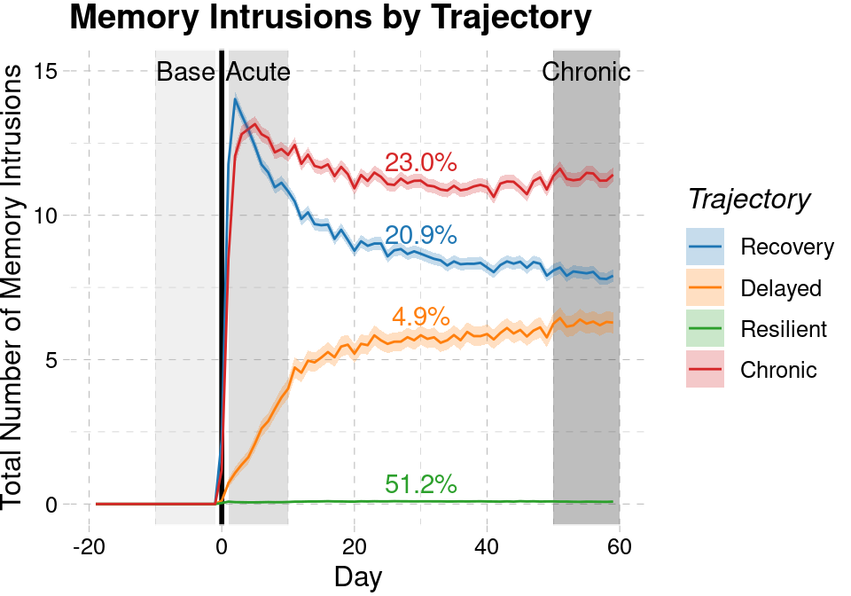

```r
K = rev(brewer.pal(5, "Greys"))

TOTAL <- 28800  # Param combos

traj_total <- a %>%
  filter(Day == 30) %>%
  group_by(Trajectory) %>%
  summarise(N = length(CTraumatic),
            Prop = length(CTraumatic)/TOTAL,
            MeanC = mean(CTraumatic))

ggplot(filter(a, I != 1),
       aes(x=Day, y=CTraumatic, col=Trajectory, fill=Trajectory)) +
  ggtitle("Memory Intrusions by Trajectory") +
  #geom_vline(data=props, aes(xintercept=-0.5)) +
  annotate("segment", x=-0, xend=-0,
           y=-Inf, yend=Inf, col="black", lty=1, size=1) +
  annotate("rect", xmin=50, xmax=60,
           ymin=-Inf, ymax=Inf, fill=K[1], alpha=0.3)+
  annotate("rect", xmin=1, xmax=10,
           ymin=-Inf, ymax=Inf, fill=K[3], alpha=0.3)+
  annotate("rect", xmin=-10, xmax=-1,
           ymin=-Inf, ymax=Inf, fill=K[4], alpha=0.3)+

  annotate("text", x= -5.5, y=15, label="Base")+
  annotate("text", x= 5.5, y=15, label="Acute")+
  annotate("text", x= 55, y=15, label="Chronic")+

  geom_text(data=traj_total, aes(x= 30, y = MeanC,
                                 label=percent(Prop, accuracy = 0.1)),
            vjust=-.5, show.legend=F) +

  stat_summary(fun.data = mean_se, geom="line") +
  stat_summary(fun.data = mean_cl_normal,
               geom="ribbon", alpha = 0.25, col=NA) +
  coord_cartesian(ylim=c(0, 15)) +
  ylab("Total Number of Memory Intrusions") +
  scale_color_d3() +
  scale_fill_d3() +
  theme_pander()
```

```r
ggsave("figures/figure6.png", dpi = 300)
```

The results indicate that our classification was correct; the trajectories behave as planned.

## Finding a baseline to compare the model to existing literature

Since we have no idea how typical the model parameters are of the existing patients and their cases, we need to provide some sort of baselines. To do so, we will use the proportion of trajectories that were given by Galatzer-Levy and Bonanno in their meta-analysis. They are:

- Resilient, 0.657
- Recovery, 0.208
- Chronic, 0.106
- Delayed, 0.089

Note that they do not normalize to one, due to the lack of some trajectories in some studies. To use them, we will need to make sure to normalized them first, which can be done at time of testing.

```r
T_observed <- c(0.657, 0.208, 0.106, 0.089)
names(T_observed) <- c("Resilient", "Recovery", "Chronic", "Delayed")
```

We can now plot the percentages and the patterns by trajectory:

```r
props <- patterns %>%
  group_by(Trajectory,
           I,
           gamma,
           C,
           W,
           R,
           #A,
           ) %>%
  dplyr::summarize(N = length(Trajectory)) %>%
  dplyr::mutate(Prop = N/50)
props %>%
  pivot_wider(id_cols=c(I,
                        gamma,
                        C,
                        W,
                        R,
                        #A,
                        ),
              names_from = Trajectory,
              values_from = N,
              values_fill=0) -> test

mychi <- function(vals) {
  chisq.test(vals,
             p=T_observed,
             rescale.p=T)$statistic
}

mycorr <- function(vals) {
  cor(vals, T_observed)
}

myrmse <- function(vals) {
  v <- 50 * (T_observed/sum(T_observed))
  sqrt(mean((vals - v)^2))
}


lprops <- test %>%
  pivot_longer(cols=c("Resilient", "Recovery", "Chronic", "Delayed"),
               names_to = "Trajectory",
               values_to = "N")

lprops$Trajectory <- factor(lprops$Trajectory,
                      levels = c("Recovery", "Delayed", "Resilient",  "Chronic"))

# Suppresses X-squared approximation warnings
old.warn <- options()$warn
options(warn = -1)

atest <- lprops %>%
  group_by(I,
           gamma,
           C,
           W,
           R,
           #A,
           ) %>%
  summarise(Chi = mychi(N), r=mycorr(N), RMSE=myrmse(N))
# resets warnings
options(warn = old.warn)

test <- inner_join(test, atest)
```

This shows how correlation coefficient and $\chi^2$ are related, while the RMSE does not really capture either of them:

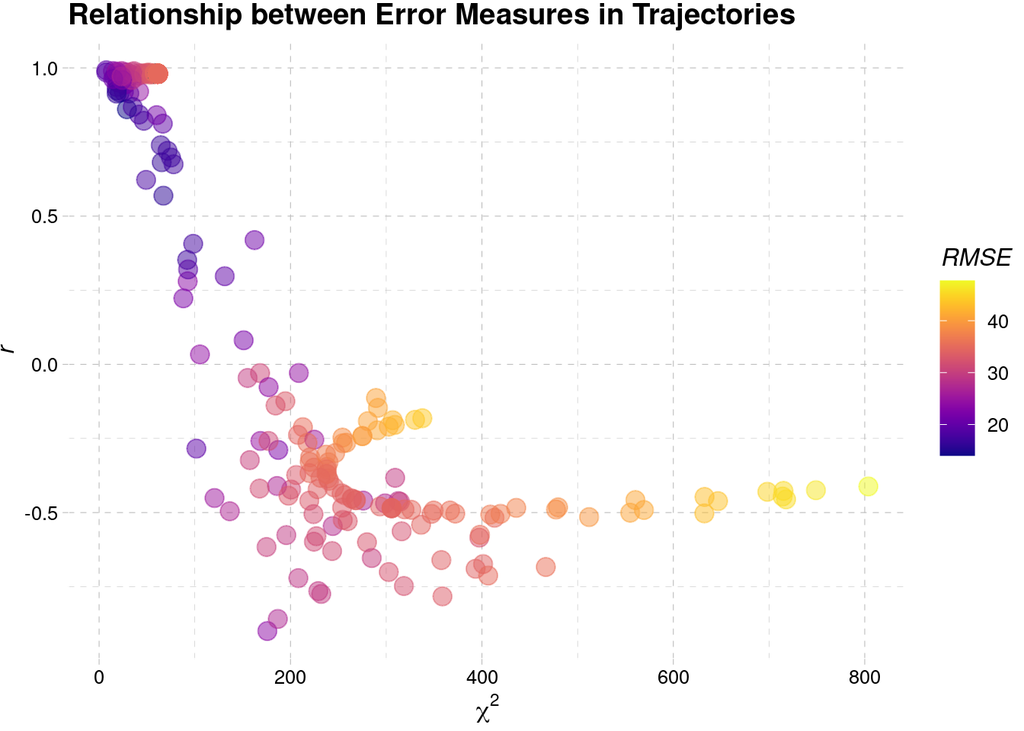

```r
ggplot(test, aes(x=Chi, y=r, col=RMSE)) +
  geom_point(size=4, alpha=0.5) +
  scale_color_viridis(option="plasma")+
  ylab(expression(italic(r))) +
  xlab(expression(chi^2)) +
  ggtitle("Relationship between Error Measures in Trajectories") +
  theme_pander()
```

Now, let’s identify a “baseline” condition—the one that most resembles the distribution of trajectories identified by Galatzer-Levy.

```r
baseline <- test %>%
  filter(Chi == min(test$Chi))

baseline %>%
  kable(digits=3) %>%
  kable_styling(bootstrap_options = c("hover", "striped"))
```

| I | gamma | C | W | R | Chronic | Delayed | Recovery | Resilient | Chi | r | RMSE |
| --- | --- | --- | --- | --- | --- | --- | --- | --- | --- | --- | --- |
| 40 | 0.9 | 0.25 | 8 | 0 | 15 | 3 | 15 | 67 | 7.464 | 0.985 | 18.875 |

And here is a visual representation of the four trajectories at that baseline (smoothed, because there is too much day-to-day variance in this small sample).

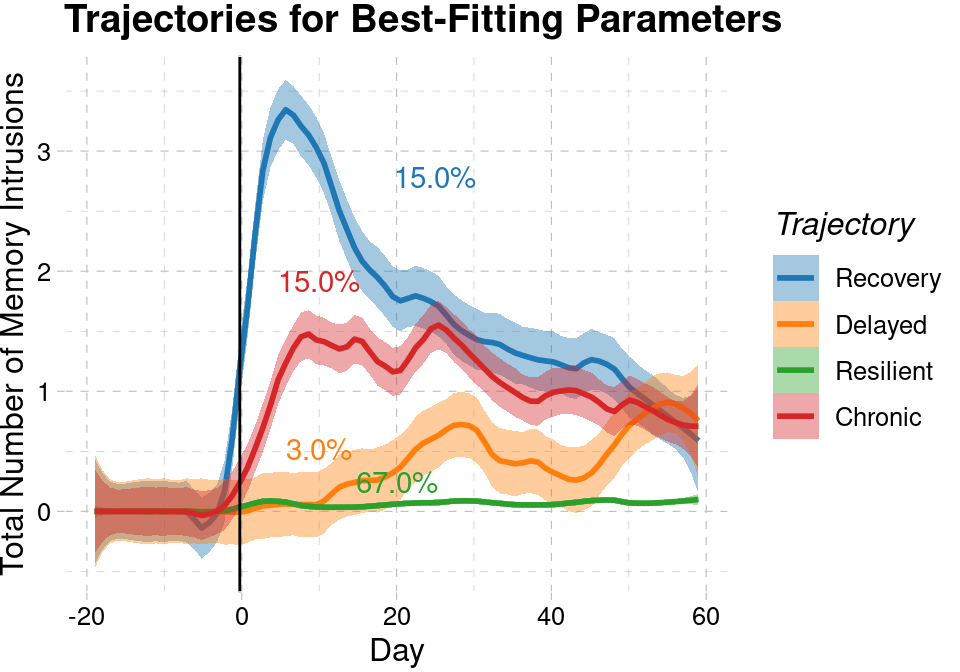

```r
baseline_a <- a %>%
  filter(I == baseline$I,
         W == baseline$W,
         C == baseline$C,
         R == baseline$R,
         gamma == baseline$gamma,
         )

base_total <- baseline_a %>%
  filter(Day == 15) %>%
  group_by(Trajectory) %>%
  summarise(N = length(CTraumatic),
            Prop = length(CTraumatic)/100,
            MeanC = mean(CTraumatic))


ggplot(baseline_a,
       aes(x=Day, y=CTraumatic, col=Trajectory, fill=Trajectory)) +
  geom_smooth(method="loess", span=0.2) +
  ggtitle("Trajectories for Best-Fitting Parameters") +
  scale_color_d3() +
  geom_text(data=base_total, aes(x= c(25, 10, 20, 10), y = MeanC,
                                 label=percent(Prop, accuracy = 0.1)),
            vjust=-.5, show.legend=F) +
  ylab("Total Number of Memory Intrusions") +
  geom_vline(data=props, aes(xintercept=-0.25)) +
  scale_fill_d3() +
  theme_pander()
```

```r
ggsave("figures/figure7.png", dpi=300)
```

The Chonic and Delayed trajectories, being the least common, exhibit significant ups and downs, hence the need for Loess smoothing. Nonetheless, the trajectories remain visible and clearly identifiable.

But how good is the baseline condition, in terms of being closed to Galatzer-Levy’s estimated pooled values? We can just examine the significance of the $\chi^2$ test.

```r
baseline_vals <- baseline[c("Resilient", "Recovery", "Chronic", "Delayed")]
chi <- chisq.test(baseline_vals, p=T_observed, rescale.p = T)
```

The result is not too bad—A bit dissimilar, but not too far either, and not statistically significant ($\chi^2$ = 7.463523, *p* = 0.058503)).

# Factors affecting the distribution of trajectories

Although theoretically possible, a full five-way analysis of model’s factors and interactions would be statistically uninformative. Instead, we will examine the model’s outcomes and behaviors with the respect to the known main effects reported in the literature.

We can now examine, one by one, how the different factor in the model affect the distribution of trajectories.

To examine these factors, we need to use logistic regression. And, to do so, we need to create a number of dummy variables specifying a binary status for each trajectory in `patterns`.

```r
patterns <- patterns %>%
  mutate(Resilient = if_else(Trajectory == "Resilient", 1, 0),
         Chronic = if_else(Trajectory == "Chronic", 1, 0),
         Recovery = if_else(Trajectory == "Recovery", 1, 0),
         Delayed = if_else(Trajectory == "Delayed", 1, 0))
```

## External factors: PTE Intensity and Context Similarity

There are two main external factors in the model: The intensity of the PTE (*I*) and the contextual similarity (*C*). They will be both examined here.

### Effects on Timecourses

First, let’s load additional values of *I* and *C* in addition to the ones in the baseline.

```r
IC_a <- a %>%
  filter(#I == baseline$I,
    I != 1,
         W == baseline$W,
         #C == baseline$C,
         R == baseline$R,
         gamma == baseline$gamma,
         #A == baseline$A
         )

IC_patterns <- patterns %>%
    filter(#I == baseline$I,
    I != 1,
         W == baseline$W,
         #C == baseline$C,
         R == baseline$R,
         gamma == baseline$gamma,
         #A == baseline$A
         )

IC_trajectories <- lprops %>%
    filter(#I == baseline$I,
    I != 1,
         W == baseline$W,
         #C == baseline$C,
         R == baseline$R,
         gamma == baseline$gamma,
         #A == baseline$A
         )


IC_traumatic <- traumatic %>%
      filter(#I == baseline$I,
         I != 1,
         W == as.numeric(baseline$W),
         #C == baseline$C,
         R == as.numeric(baseline$R),
         gamma == as.numeric(baseline$gamma),
         #A == baseline$A
         )
```

First, let’s look at the time course of intrusions:

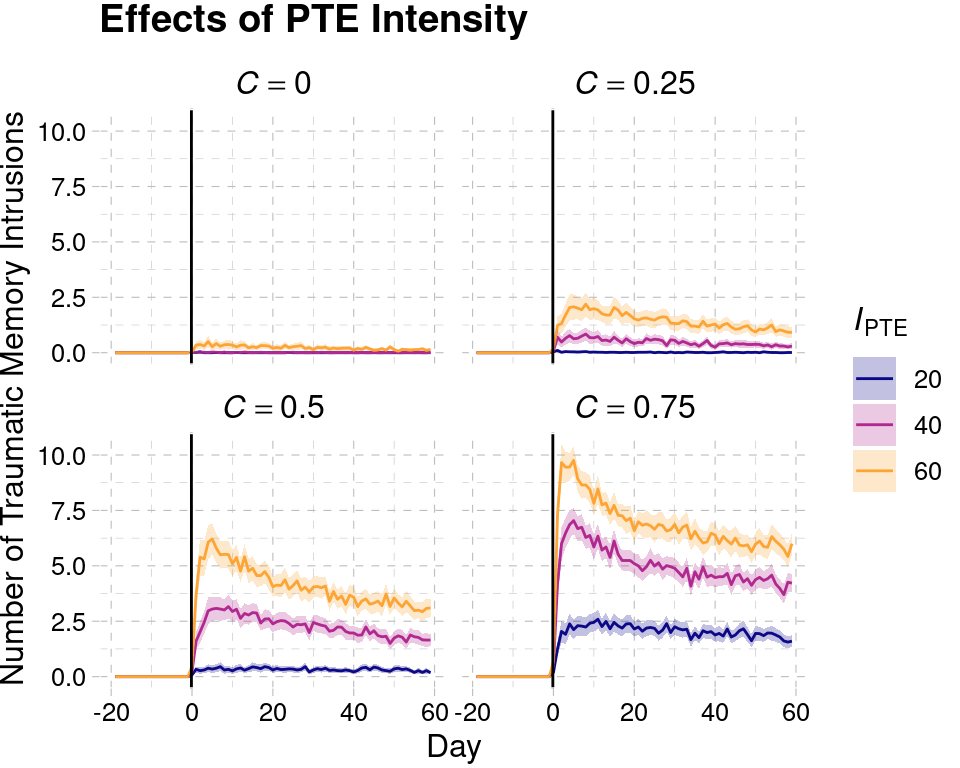

```r
ggplot(IC_a,
       aes(x=Day, y=CTraumatic, col=as.factor(I), fill=as.factor(I))) +
  #geom_smooth(method="loess", span=0.2) +
  stat_summary(fun.data = mean_se, geom="line") +
  stat_summary(fun.data = mean_cl_normal,
               geom="ribbon", alpha = 0.25, col=NA) +

  facet_wrap(~C, labeller = label_bquote(italic(C) == .(C))) + #label=label_both) +
  labs(col=expression(italic(I)[PTE]),
       fill=expression(italic(I)[PTE]),
       facet="Z") +
  #coord_cartesian(ylim=c(0, 0.5)) +
  ggtitle("Effects of PTE Intensity") +
  ylab("Number of Traumatic Memory Intrusions") +

  scale_color_viridis(discrete=T, option="plasma", end=0.8) +
  scale_fill_viridis(option = "plasma", discrete = T, end=0.8) +
  geom_vline(data=props, aes(xintercept=-0.15)) +
  theme_pander()
```

The effects of *I* and *C* on the probabilities of recall during the Chronic period can be understood with a linear model analysis

```r
IC_mod <- glm(CTraumatic ~ I * C, family="poisson", IC_traumatic)
# lm.beta(IC_mod)
#or
# glm(scale(CTraumatic) ~ scale(I) * scale(C), family="poisson", IC_traumatic)
summary(IC_mod) %>%
  xtable %>%
  kable %>%
  kable_styling(bootstrap_options = c("striped", "hover"))
```

|  | Estimate | Std. Error | z value | Pr(>\|z\|) |
| --- | --- | --- | --- | --- |
| (Intercept) | -0.7993158 | 0.0439928 | -18.16923 | 0 |
| I | 0.0842682 | 0.0008007 | 105.23676 | 0 |
| C | 7.8729269 | 0.0636742 | 123.64387 | 0 |
| I:C | -0.0739858 | 0.0011709 | -63.18745 | 0 |

And the standardized betas

```r
summary(lm.beta(IC_mod))$coefficients %>%
  xtable() %>%
  kable %>%
  kable_styling(bootstrap_options = c("striped", "hover"))
```

|  | Estimate | Standardized | Std. Error | t value | Pr(>\|t\|) |
| --- | --- | --- | --- | --- | --- |
| (Intercept) | -0.7993158 | 0.0000000 | 0.2207885 | -3.620278 | 0.0003193 |
| I | 0.0842682 | 0.0053397 | 0.0040187 | 20.968764 | 0.0000000 |
| C | 7.8729269 | 0.0085389 | 0.3195643 | 24.636442 | 0.0000000 |
| I:C | -0.0739858 | -0.0038872 | 0.0058764 | -12.590305 | 0.0000000 |

### Effects on Trajectories

And here are the changes in trajectories.

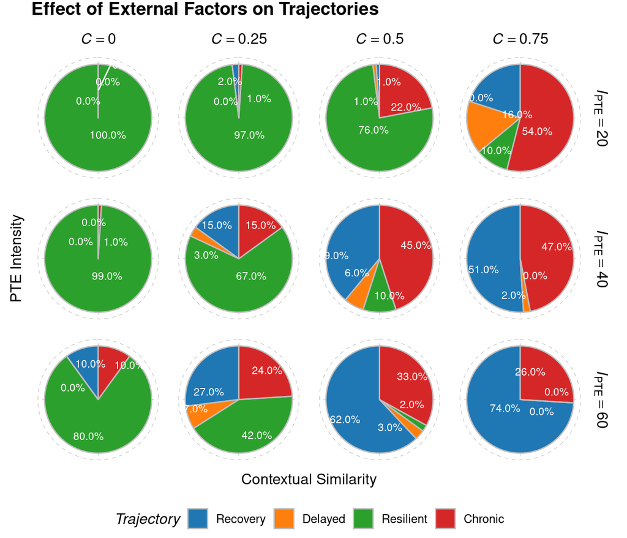

```r
ggplot(data=IC_trajectories, aes(x="", y=N/100, fill=Trajectory)) +
  geom_bar(stat = "identity", col="grey", width=1) +
  #facet_grid(C~I, labeller = label_both) +
  facet_grid(I~C, labeller = label_bquote(
    cols = italic(C) == .(C),
    rows = italic(I)[PTE] == .(I))) +
  coord_polar("y", start=0) +
  scale_y_continuous(labels = scales::percent_format(accuracy = 2L)) +
  scale_fill_d3() +
  scale_color_d3() +
  xlab("PTE Intensity") +
  ylab("Contextual Similarity") +
  ggtitle("Effect of External Factors on Trajectories") +
  geom_text_repel(aes(label=percent(N/100, .1)), col="white",
            position=position_stack(vjust=0.5 ), size=3)+
  theme_pander() +
  theme(axis.ticks = element_blank(),
        axis.text.y = element_blank(),
        axis.text.x = element_blank(),
        legend.position = "bottom")
```

Are the change in trajectories meaningful? To do so, we first examine the trajectories using a MANOVA:

```r
man <- manova(cbind(Resilient, Recovery, Delayed) ~ I * C, IC_patterns)
tidy(man) %>%
  xtable() %>%
  kable() %>%
  kable_styling(bootstrap_options = c("hover", "striped"))
```

| term | df | pillai | statistic | num.df | den.df | p.value |
| --- | --- | --- | --- | --- | --- | --- |
| I | 1 | 0.2505389 | 133.0483 | 3 | 1194 | 0 |
| C | 1 | 0.5364246 | 460.5442 | 3 | 1194 | 0 |
| I:C | 1 | 0.0589542 | 24.9337 | 3 | 1194 | 0 |
| Residuals | 1196 | NA | NA | NA | NA | NA |

Then, we examine each category independently, we will perform a logistic regression on dummy binary variables that categorize each run of the model as belonging to that category, or not.

In the case of the Resilient and Recovery trajectories, both intensity *I*, Context *C* are significant, but their interaction is not. This implies that the effects of *I* and *C* are additive.

#### Resilient Trajectory

```r
mylogit <- glm(Resilient ~ (I*C), family="binomial", data=IC_patterns)
summary(lm.beta(mylogit))$coefficients %>%
  xtable() %>%
  kable() %>%
  kable_styling(bootstrap_options = c("hover", "striped"))
```

|  | Estimate | Standardized | Std. Error | t value | Pr(>\|t\|) |
| --- | --- | --- | --- | --- | --- |
| (Intercept) | 8.0726911 | 0.0000000 | 0.6295248 | 12.8234677 | 0.000000 |
| I | -0.1042898 | -3.4074582 | 0.0120331 | -8.6669004 | 0.000000 |
| C | -10.3446128 | -5.7851369 | 1.1952394 | -8.6548458 | 0.000000 |
| I:C | -0.0144672 | -0.3919321 | 0.0274853 | -0.5263624 | 0.598734 |

#### Recovery Trajectory

For Recovery trajectories, however, the coefficients are significantly positive, implying that the number of cases increase with the severity of intensity and similarity. This is likely due to a greater number of resilient models developing intrusive memories following PTE under greater contextual similarity.

```r
mylogit <- glm(Recovery ~ (I*C), family="binomial", data=IC_patterns)
summary(lm.beta(mylogit))$coefficients %>%
  xtable() %>%
  kable() %>%
  kable_styling(bootstrap_options = c("hover", "striped"))
```

|  | Estimate | Standardized | Std. Error | t value | Pr(>\|t\|) |
| --- | --- | --- | --- | --- | --- |
| (Intercept) | -6.5266334 | 0.0000000 | 0.7228885 | -9.0285476 | 0.0000000 |
| I | 0.0757766 | 2.8545490 | 0.0135506 | 5.5921221 | 0.0000000 |
| C | 5.0969156 | 3.2864014 | 1.1602929 | 4.3927835 | 0.0000122 |
| I:C | -0.0085358 | -0.2666156 | 0.0228020 | -0.3743471 | 0.7082125 |

#### Chronic Trajectory

In the case of Chronic and Delayed trajectories, however, the pattern is different. In these cases, both the main factors and their interaction are significant. Furthermore, in both cases, the main factors have positive coefficients but their interaction is negative. This suggests that the effects of one factor decrease the size of the other factor increases.

```r
mylogit <- glm(Chronic ~ (I*C), family="binomial", data=IC_patterns)
summary(lm.beta(mylogit))$coefficients %>%
  xtable() %>%
  kable() %>%
  kable_styling(bootstrap_options = c("hover", "striped"))
```

|  | Estimate | Standardized | Std. Error | t value | Pr(>\|t\|) |
| --- | --- | --- | --- | --- | --- |
| (Intercept) | -6.2050051 | 0.000000 | 0.5847010 | -10.612270 | 0 |
| I | 0.0760648 | 2.944162 | 0.0112577 | 6.756722 | 0 |
| C | 9.4454215 | 6.257628 | 0.9624016 | 9.814428 | 0 |
| I:C | -0.1332185 | -4.275418 | 0.0191777 | -6.946516 | 0 |

#### Delayed Trajectory

```r
mylogit <- glm(Delayed ~ (I*C), family="binomial", data=IC_patterns)
summary(lm.beta(mylogit))$coefficients %>%
  xtable() %>%
  kable() %>%
  kable_styling(bootstrap_options = c("hover", "striped"))
```

|  | Estimate | Standardized | Std. Error | t value | Pr(>\|t\|) |
| --- | --- | --- | --- | --- | --- |
| (Intercept) | -9.2380905 | 0.000000 | 1.5990664 | -5.777177 | 0.0000000 |
| I | 0.1004351 | 9.366045 | 0.0292574 | 3.432807 | 0.0006178 |
| C | 11.4814812 | 18.326491 | 2.3393831 | 4.907910 | 0.0000010 |
| I:C | -0.2098212 | -16.223945 | 0.0460414 | -4.557228 | 0.0000057 |

## Internal Factors: Working Memory and Recollection Vividness

The internal factors are two, differences in WMC and differences in vividness.

This can be related to the difference in children.

```r
Wg_a <- a %>%
  filter(I == baseline$I,
         #W == baseline$W,
         C == baseline$C,
         R == baseline$R,
         #gamma == baseline$gamma,
         #A == baseline$A
         )

Wg_test <- lprops %>%
    filter(I == baseline$I,
         #W == baseline$W,
         C == baseline$C,
         R == baseline$R,
         #gamma == baseline$gamma,
         #A == baseline$A
         )

Wg_patterns <- patterns %>%
    filter(I == baseline$I,
         #I != 1,
         #W == as.numeric(baseline$W),
         C == baseline$C,
         R == as.numeric(baseline$R),
         #gamma == as.numeric(baseline$gamma),
         #A == baseline$A
         )

Wg_traumatic <- traumatic %>%
    filter(I == baseline$I,
         #I != 1,
         #W == as.numeric(baseline$W),
         C == baseline$C,
         R == as.numeric(baseline$R),
         #gamma == as.numeric(baseline$gamma),
         #A == baseline$A
         )
```

### Effects on the Timecourse of Intrusive Memories

Here we visualize the change in timecourses.

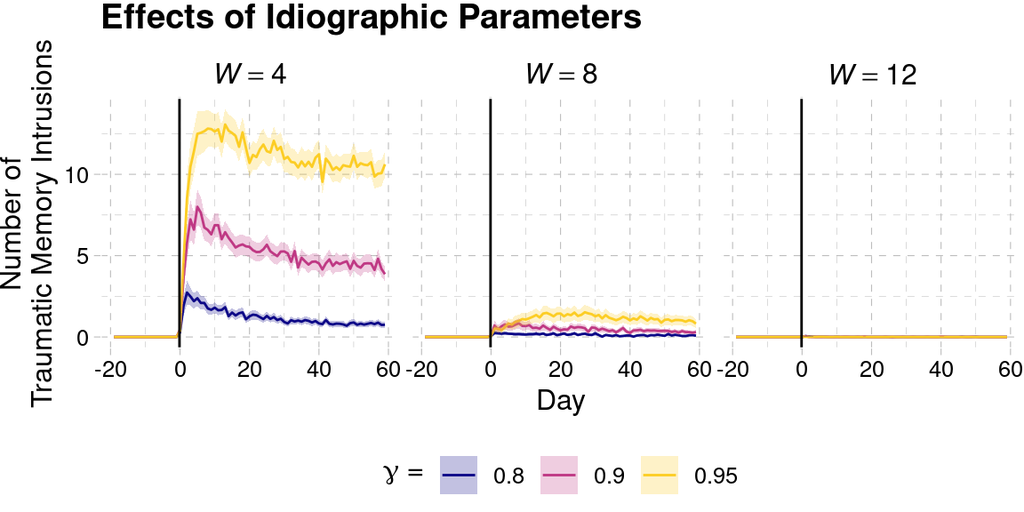

```r
Wg_a$gamma <- as_factor(Wg_a$gamma)
ggplot(Wg_a,
       aes(x=Day, y=CTraumatic, col=gamma, fill=gamma)) +
#  geom_point(alpha=0.1) +
  stat_summary(fun.data = mean_se, geom="line") +
  stat_summary(fun.data = mean_cl_normal,
               geom="ribbon", alpha = 0.25, col=NA) +

  #geom_smooth(method="loess", span=0.2) +
  facet_wrap(~W, ncol=3,
             labeller  = label_bquote(
               rows = italic(W) == .(W))) +
  geom_vline(data=props, aes(xintercept=-0.15)) +
  ylab("Number of\nTraumatic Memory Intrusions") +
  #coord_cartesian(ylim=c(0, 0.75)) +
  ggtitle("Effects of Idiographic Parameters") +
  scale_color_viridis(expression(paste(gamma, " =")), discrete=T,
                      option="plasma", begin = 0, end=0.9) +
  scale_fill_viridis(expression(paste(gamma, " =")), option = "plasma",
                     discrete = T, begin = 0, end=0.9) +
  theme_pander() +
  theme(legend.position = "bottom")
```

It is striking to notice that, within baseline levels of *I* and *C*, the effects of working memory are incredibly large. This is likely due to the fact that the parameters were not properly calibrated.

And here is the corresponding analysis. Like before, the main factors *W* and $\gamma$ are significant. However, this time, their interaction is not, suggesting that their effects are additive.

```r
Wg_mod <- glm(CTraumatic ~ W * gamma, family="poisson", Wg_traumatic)
summary(Wg_mod) %>%
  xtable %>%
  kable %>%
  kable_styling(bootstrap_options = c("striped", "hover"))
```

|  | Estimate | Std. Error | z value | Pr(>\|z\|) |
| --- | --- | --- | --- | --- |
| (Intercept) | -4.6088943 | 0.2487333 | -18.5294648 | 0.0000000 |
| W | -0.5902732 | 0.0547969 | -10.7720158 | 0.0000000 |
| gamma | 15.0052321 | 0.2687441 | 55.8346535 | 0.0000000 |
| W:gamma | -0.0295063 | 0.0592083 | -0.4983467 | 0.6182397 |

And the standardized betas

```r
summary(lm.beta(Wg_mod))$coefficients %>%
  xtable() %>%
  kable %>%
  kable_styling(bootstrap_options = c("striped", "hover"))
```

|  | Estimate | Standardized | Std. Error | t value | Pr(>\|t\|) |
| --- | --- | --- | --- | --- | --- |
| (Intercept) | -4.6088943 | 0.0000000 | 1.1033290 | -4.1772621 | 0.0000355 |
| W | -0.5902732 | -0.0045824 | 0.2430677 | -2.4284313 | 0.0155587 |
| gamma | 15.0052321 | 0.0022242 | 1.1920927 | 12.5873026 | 0.0000000 |
| W:gamma | -0.0295063 | -0.0002058 | 0.2626357 | -0.1123467 | 0.9105990 |

### Effects on Trajectories

And here are the changes in trajectories.

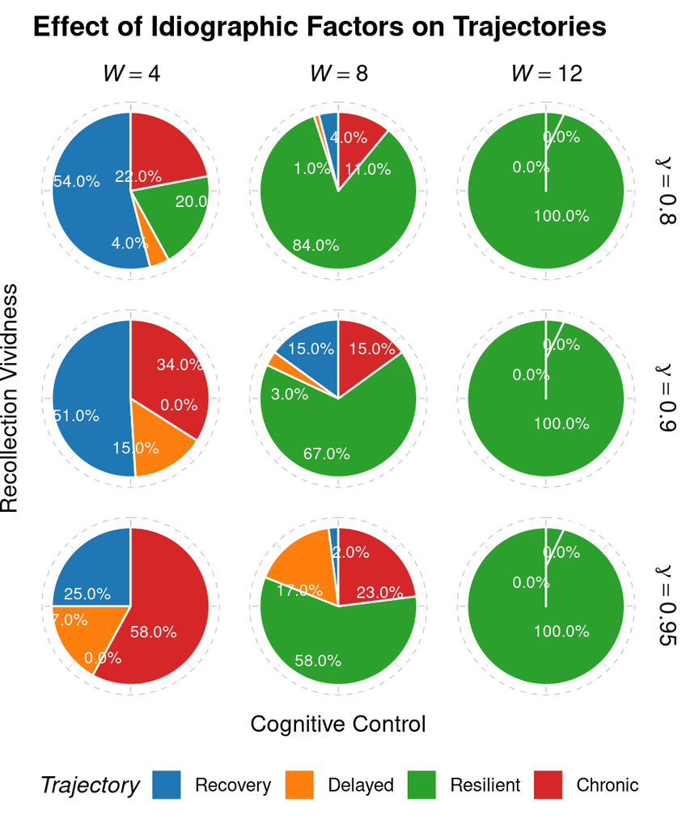

```r
ggplot(data=Wg_test, aes(x="", y=N/100, fill=Trajectory)) +
  geom_bar(stat = "identity", col="white", width=1, alpha=1) +
  facet_grid(gamma~W,
             labeller  = label_bquote(
               rows = gamma == .(gamma),
               cols = italic(W) == .(W))) +
  coord_polar("y", start=0) +
  #scale_fill_d3() +
  scale_y_continuous(labels = scales::percent_format(accuracy = 2L)) +
  scale_fill_d3() +
  xlab("Recollection Vividness") +
  ylab("Cognitive Control") +
  ggtitle("Effect of Idiographic Factors on Trajectories") +
  geom_text_repel(aes(label=percent(N/100, .1)),
            position=position_stack(vjust=0.5), size=3, col="white") +
  #geom_text_repel() +
  theme_pander() +
  theme(axis.ticks = element_blank(),
        axis.text.y = element_blank(),
        axis.text.x = element_blank(),
        legend.position = "bottom")
```

As before, we can start with a MANOVA:

```r
man <- manova(cbind(Resilient, Recovery, Delayed) ~ W * gamma, Wg_patterns)
tidy(man) %>%
  xtable() %>%
  kable() %>%
  kable_styling(bootstrap_options = c("hover", "striped"))
```

| term | df | pillai | statistic | num.df | den.df | p.value |
| --- | --- | --- | --- | --- | --- | --- |
| W | 1 | 0.6151552 | 476.33812 | 3 | 894 | 0 |
| gamma | 1 | 0.0818391 | 26.56184 | 3 | 894 | 0 |
| W:gamma | 1 | 0.0478437 | 14.97384 | 3 | 894 | 0 |
| Residuals | 896 | NA | NA | NA | NA | NA |

The MANOVA shows that both factors and their interactions are significant. We can now carry out a trajectory by trajectory analysis.

Because of the large varince in the proportion of trajectories (due to the massive effects of *W*), none of the interaction terms are significant. Thus, we analyzed all four trajectories with a simpler generalized linear model of the form $Y = \beta_0 + \beta_W W + \beta_{\gamma} \gamma + \epsilon$, using a logistic link function.

#### Resilient Trajectory

```r
mylogit <- glm(Resilient ~ W + gamma,
                  family = binomial("logit"),
                  data = Wg_patterns)
summary(lm.beta(mylogit))$coefficients  %>%
  xtable() %>%
  kable() %>%
  kable_styling(bootstrap_options = c("hover", "striped"))
```

|  | Estimate | Standardized | Std. Error | t value | Pr(>\|t\|) |
| --- | --- | --- | --- | --- | --- |
| (Intercept) | 4.751373 | 0.000000 | 1.3433825 | 3.536872 | 0.0004256 |
| W | 1.034876 | 6.866420 | 0.0538621 | 19.213435 | 0.0000000 |
| gamma | -13.553966 | -1.717145 | 1.6517751 | -8.205697 | 0.0000000 |

#### Chronic Trajectory

We can then examine the *Chronic* trajectory:

```r
mylogit <- glm(Chronic ~ (W + gamma), family=binomial("logit"),
               data=Wg_patterns)
summary(lm.beta(mylogit))$coefficients %>%
  xtable() %>%
  kable() %>%
  kable_styling(bootstrap_options = c("hover", "striped"))
```

|  | Estimate | Standardized | Std. Error | t value | Pr(>\|t\|) |
| --- | --- | --- | --- | --- | --- |
| (Intercept) | -6.5273256 | 0.000000 | 1.3864020 | -4.708105 | 2.9e-06 |
| W | -0.4288011 | -3.636514 | 0.0366568 | -11.697723 | 0.0e+00 |
| gamma | 8.8505973 | 1.433179 | 1.5553780 | 5.690319 | 0.0e+00 |

#### Recovery Trajectory

Then, we on the Recovery trajectory.

```r
mylogit <- glm(Recovery ~ (W + gamma), family=binomial("logit"),
               data=filter(Wg_patterns, W<13))
summary(lm.beta(mylogit))$coefficients %>%
  xtable() %>%
  kable() %>%
  kable_styling(bootstrap_options = c("hover", "striped"))
```

|  | Estimate | Standardized | Std. Error | t value | Pr(>\|t\|) |
| --- | --- | --- | --- | --- | --- |
| (Intercept) | 7.0495506 | 0.0000000 | 1.3311298 | 5.295915 | 0.0000001 |
| W | -0.6371039 | -5.5684943 | 0.0507284 | -12.559119 | 0.0000000 |
| gamma | -5.3828643 | -0.8983371 | 1.4564207 | -3.695954 | 0.0002323 |

#### Delayed Trajectory

The *Delayed* trajectory:

```r
mylogit <- glm(Delayed ~ (W + gamma),
               family=binomial("logit"),
               data=filter(Wg_patterns, W < 20) )
summary(lm.beta(mylogit))$coefficients %>%
  xtable() %>%
  kable() %>%
  kable_styling(bootstrap_options = c("hover", "striped"))
```

|  | Estimate | Standardized | Std. Error | t value | Pr(>\|t\|) |
| --- | --- | --- | --- | --- | --- |
| (Intercept) | -13.3386513 | 0.000000 | 2.550212 | -5.230410 | 2e-07 |
| W | -0.3133589 | -4.201919 | 0.049466 | -6.334835 | 0e+00 |
| gamma | 14.1075665 | 3.612070 | 2.771561 | 5.090115 | 4e-07 |

## Comorbidty: Effects of Rumination

```r
R_a <- a %>%
  filter(I == baseline$I,
         W == baseline$W,
         C == baseline$C,
         #R == baseline$R,
         gamma == baseline$gamma,
         #A == baseline$A
         )

R_test <- lprops %>%
    filter(I == baseline$I,
         W == baseline$W,
         C == baseline$C,
         #R == baseline$R,
         gamma == baseline$gamma,
         #A == baseline$A
         )

R_patterns <- patterns %>%
    filter(I == baseline$I,
         #I != 1,
         W == as.numeric(baseline$W),
         C == baseline$C,
         #R == as.numeric(baseline$R),
         gamma == as.numeric(baseline$gamma),
         #A == baseline$A
         )

R_traumatic <- traumatic %>%
    filter(I == baseline$I,
         #I != 1,
         W == as.numeric(baseline$W),
         C == baseline$C,
         #R == as.numeric(baseline$R),
         gamma == as.numeric(baseline$gamma),
         #A == baseline$A
         )
```

### Effects on the Timecourse of Intrusive Memories

Here we visualize the change in timecourses.

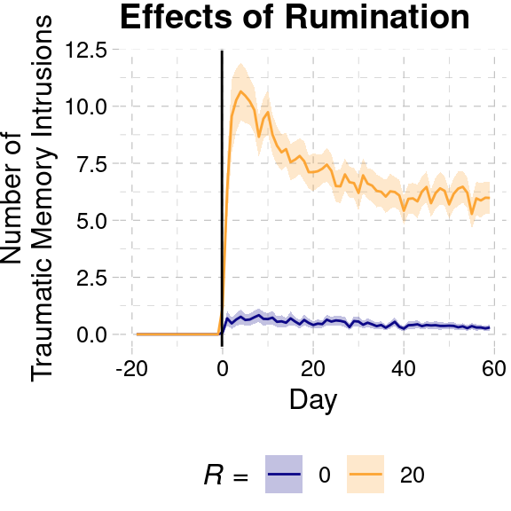

```r
ggplot(R_a,
       aes(x=Day, y=CTraumatic, col=as.factor(R), fill=as.factor(R))) +
  stat_summary(fun.data = mean_se, geom="line") +
  stat_summary(fun.data = mean_cl_normal,
               geom="ribbon", alpha = 0.25, col=NA) +
  geom_vline(data=props, aes(xintercept=-0.15)) +

  #geom_smooth(method="loess", span=0.2) +
  #facet_wrap(~R) +
  #coord_cartesian(ylim=c(0, 0.75)) +
  ylab("Number of\nTraumatic Memory Intrusions") +
  #coord_cartesian(ylim=c(0, 0.75)) +
  ggtitle("Effects of Rumination") +
  scale_color_viridis(expression(paste(italic(R), " =")), discrete=T, option="plasma", end=0.8) +
  scale_fill_viridis(expression(paste(italic(R), " =")), option = "plasma", discrete = T, end=0.8) +
  theme_pander() +
  theme(legend.position = "bottom")
```

The effects of Rumination are huge. This is likely due to the fact that the parameters were not properly calibrated.

```r
R_mod <- glm(CTraumatic ~ R, family="poisson", R_traumatic)
summary(R_mod) %>%
  xtable %>%
  kable %>%
  kable_styling(bootstrap_options = c("striped", "hover"))
```

|  | Estimate | Std. Error | z value | Pr(>\|z\|) |
| --- | --- | --- | --- | --- |
| (Intercept) | 4.0167433 | 0.0189797 | 211.6333 | 0 |
| R | 0.1350059 | 0.0009804 | 137.7115 | 0 |

And the standardized betas

```r
summary(lm.beta(R_mod))$coefficients %>%
  xtable() %>%
  kable %>%
  kable_styling(bootstrap_options = c("striped", "hover"))
```

|  | Estimate | Standardized | Std. Error | t value | Pr(>\|t\|) |
| --- | --- | --- | --- | --- | --- |
| (Intercept) | 4.0167433 | 0.0000000 | 0.1091558 | 36.79825 | 0 |
| R | 0.1350059 | 0.0033364 | 0.0056382 | 23.94492 | 0 |

### Effects on Trajectories

And here are the changes in trajectories.

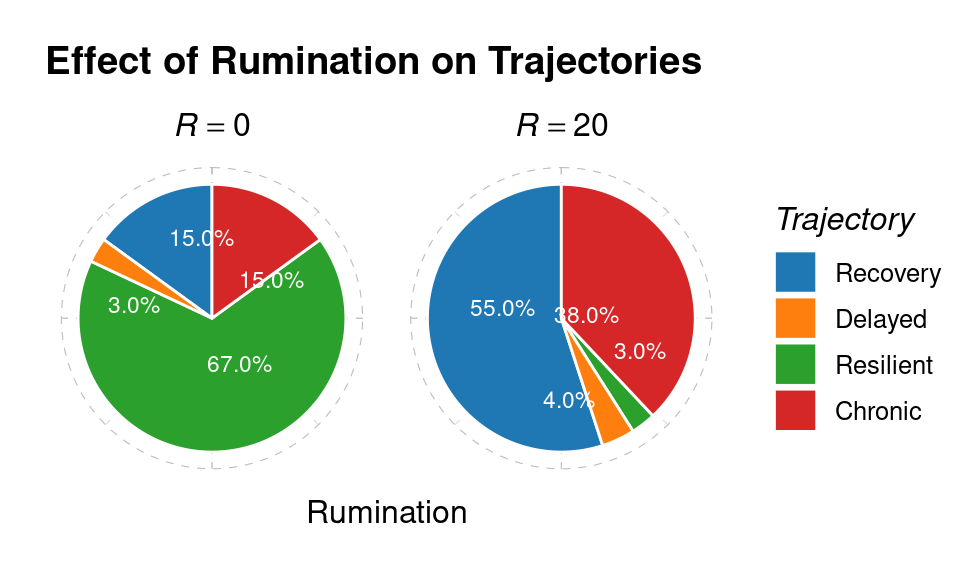

```r
ggplot(data=R_test, aes(x="", y=N/100, fill=Trajectory)) +
  geom_bar(stat = "identity", col="white", width=1, alpha=1) +
  facet_wrap(~ R, labeller = label_bquote(
               rows = italic(R) == .(R))) +
  coord_polar("y", start=0) +
  #scale_fill_d3() +
  scale_y_continuous(labels = scales::percent_format(accuracy = 2L)) +
  scale_fill_d3() +
  ylab("Rumination") +
  xlab("") +
  ggtitle("Effect of Rumination on Trajectories") +
  geom_text_repel(aes(label=percent(N/100, .1)),
            position=position_stack(vjust=0.5), size=3, col="white") +
  #geom_text_repel() +
  theme_pander() +
  theme(axis.ticks = element_blank(),
        axis.text.y = element_blank(),
        axis.text.x = element_blank())
```

As before, we can start with a MANOVA:

```r
man <- manova(cbind(Resilient, Recovery, Delayed) ~ R, R_patterns)
tidy(man) %>%
  xtable() %>%
  kable() %>%
  kable_styling(bootstrap_options = c("hover", "striped"))
```

| term | df | pillai | statistic | num.df | den.df | p.value |
| --- | --- | --- | --- | --- | --- | --- |
| R | 1 | 0.4574771 | 55.09169 | 3 | 196 | 0 |
| Residuals | 198 | NA | NA | NA | NA | NA |

The MANOVA shows that rumination is significant. We can now carry out a trajectory by trajectory analysis.

#### Resilient Trajectory

First, we can examine the effects on the *Resilient* trajectory.

```r
mylogit <- glm(Resilient ~ R,
               family = "binomial",
               data = R_patterns)
summary(lm.beta(mylogit))$coefficients %>%
  xtable() %>%
  kable() %>%
  kable_styling(bootstrap_options = c("hover", "striped"))
```

|  | Estimate | Standardized | Std. Error | t value | Pr(>\|t\|) |
| --- | --- | --- | --- | --- | --- |
| (Intercept) | 0.7081851 | 0.000000 | 0.2137413 | 3.313281 | 0.0010963 |
| R | -0.2092142 | -4.386321 | 0.0313368 | -6.676306 | 0.0000000 |

#### Chronic Trajectory

We can then examine the *Chronic* trajectory:

```r
mylogit <- glm(Chronic ~ R, family="binomial", data=R_patterns)
summary(lm.beta(mylogit))$coefficients %>%
  xtable() %>%
  kable() %>%
  kable_styling(bootstrap_options = c("hover", "striped"))
```

|  | Estimate | Standardized | Std. Error | t value | Pr(>\|t\|) |
| --- | --- | --- | --- | --- | --- |
| (Intercept) | -1.7346011 | 0.000000 | 0.2814669 | -6.162718 | 0.0000000 |
| R | 0.0622526 | 1.410559 | 0.0174712 | 3.563157 | 0.0004591 |

#### Recovery Trajctory

The, we analyze the Recovery trajectory.

```r
mylogit <- glm(Recovery ~ R, family="binomial", data = R_patterns)
summary(lm.beta(mylogit))$coefficients %>%
  xtable() %>%
  kable() %>%
  kable_styling(bootstrap_options = c("hover", "striped"))
```

|  | Estimate | Standardized | Std. Error | t value | Pr(>\|t\|) |
| --- | --- | --- | --- | --- | --- |
| (Intercept) | -1.7346010 | 0.000000 | 0.2814500 | -6.163088 | 0e+00 |
| R | 0.0967636 | 2.028716 | 0.0173228 | 5.585923 | 1e-07 |

And, finally, The *Delayed* trajectory:

```r
mylogit <- glm(Delayed ~ R,
               family="binomial",
               data=R_patterns)
summary(lm.beta(mylogit))$coefficients %>%
  xtable() %>%
  kable() %>%
  kable_styling(bootstrap_options = c("hover", "striped"))
```

|  | Estimate | Standardized | Std. Error | t value | Pr(>\|t\|) |
| --- | --- | --- | --- | --- | --- |
| (Intercept) | -3.4760987 | 0.0000000 | 0.5891631 | -5.9000622 | 0.0000000 |
| R | 0.0149022 | 0.8108751 | 0.0390564 | 0.3815571 | 0.7031991 |

# Neurobiology of PTSD

Finally, we will examine how the model captures some known effects of the neurobiology of PTSD and, in particular, the size of the hippocampus.

## Hippocampus Size

```r
H1 <- a %>%
  filter(I == 1 & gamma == 0.9 & C==0.25 & R == 0 & Day > 49) %>%
  dplyr::select(MemoryEntropy) %>%
  summarise(H=mean(MemoryEntropy)) %>%
  as.double()
```

Then, we define a function that calculates memory entropy on the last *N* days of a timeseries.

```r
h_entropy <- function(timeseries, N = 10) {
  L <- length(timeseries)
  mean(timeseries[L-N:N])
}
```

With this in place, we can now calculate the predicted decrease in hippocampus size.

```r
hsize <- a %>%
  filter(Day > 49) %>%
  group_by(Run, I, C, R, W, gamma, Trajectory) %>%
  dplyr::summarize(H = h_entropy(MemoryEntropy) - H1,
            HippocampusDecrease = 100*(mean(MemoryEntropy)/H1 - 1),
            MeanTraumatic = mean(PTraumatic),
            NumTraumatic = sum(CTraumatic),
            MeanSimilarity = mean(ChunkSimilarity),
            Trajectory = )
```

### Visualizing Hippocampus Volume Decrease

For pretty labels, we define two new labeller functions:

```r
ptev_val <- function(val) {
  paste("I =", val)
}

gamma_val <- function(val) {
  #expression(paste(gamma, "=", val))
  paste("gamma =", val)
}
```

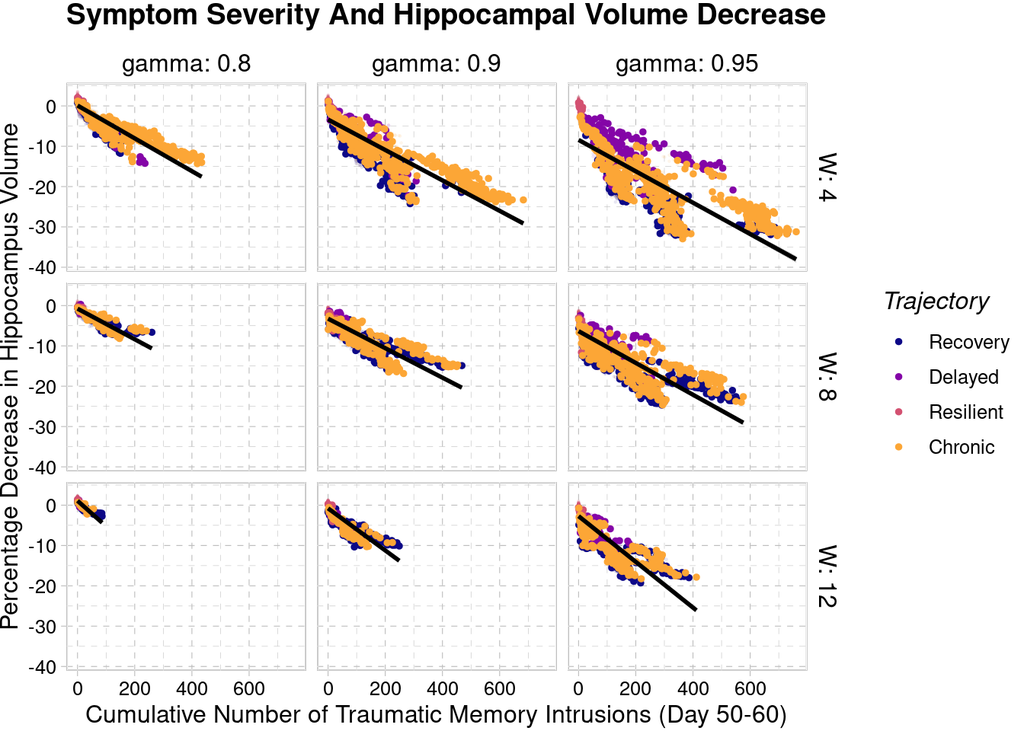

```r
hsize <- hsize %>%
  mutate(External = paste("I = ", I , ", C = ", C))

ggplot(filter(hsize, I != 1),
       aes(x=NumTraumatic, y=HippocampusDecrease, col = Trajectory)) +
  geom_point(alpha=0.1, size=0.1, pch=21) +
  #geom_density_2d() +
  facet_grid( W ~ gamma, labeller=label_both) +
  #scale_color_brewer(palette="Paired") +
  scale_color_viridis(option = "plasma", discrete = T, end = 0.8) +
  stat_summary(fun.data = mean_se, geom="point", size=1) +
  geom_smooth(method = "lm", formula = y ~ x, col="black", fullrange= F) +
  #geom_smooth(method = "lm", aes(fill=Condition), se=F) +
  ylab("Percentage Decrease in Hippocampus Volume") +
  xlab("Cumulative Number of Traumatic Memory Intrusions (Day 50-60)") +
  ggtitle("Symptom Severity And Hippocampal Volume Decrease") +
  theme_pander() +
#  theme(legend.position = "bottom") +
  theme(panel.background=element_rect(fill="NA", colour="black"))
```

By Trajectory

```r
hsize_trajectory <- a %>%
  filter(Day > 49, I != 1) %>%
  group_by(Run, I, C, R, W, gamma, Trajectory) %>%
  dplyr::summarize(HippocampusDecrease = 100*(mean(MemoryEntropy)/H1 - 1),
                   PTraumatic = mean(PTraumatic),
                   CTraumatic = sum(CTraumatic),
                   MeanSimilarity = mean(ChunkSimilarity))
```

And here is the corresponding plot:

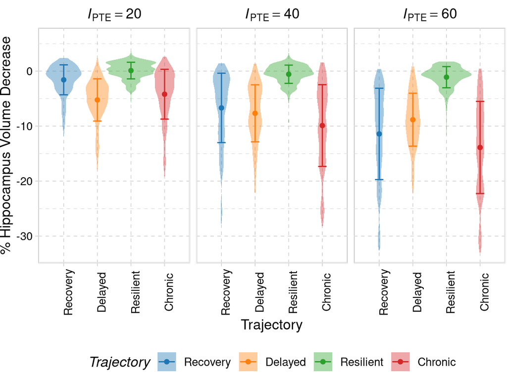

```r
ggplot(hsize_trajectory, aes(x=Trajectory, y = HippocampusDecrease,
                             col=Trajectory, fill=Trajectory)) +
  facet_wrap(~I, labeller = label_bquote(
    rows = italic(I)[PTE] == .(I))) +
  scale_fill_d3() +
  scale_color_d3() +
  stat_summary(geom="point", fun.data="mean_sdl") +
  stat_summary(geom="errorbar", fun.data="mean_sdl", width=.25,
               fun.args = list(mult=1)) +
  #geom_boxplot(width=.25, fill=NA) +
  geom_violin(alpha=0.4, col="NA", trim = T, width  = 1.5) +
  theme_pander() +
  ylab("% Hippocampus Volume Decrease") +
  theme(axis.text.x = element_text(angle = 90)) +
  theme(panel.background=element_rect(fill="NA", colour="black"),
        legend.position = "bottom")
```

In general, largest decreases of hippocampus occur in the Chronic trajectory, and the smaller decreases in the resilient ones. But is a larger decrease inverse;y associated with the proportion of resilient trajectories?

```r
hsize_traj_prop <- hsize_trajectory %>%
  mutate(IsResilient = ifelse(Trajectory=="Resilient", 1, 0)) %>%
  group_by(I, C, R, W, gamma) %>%
  summarise(HippocampusDecrease = mean(HippocampusDecrease),
          PropResilient = mean(IsResilient),
          LogVolume = log(100 + HippocampusDecrease))
```

Now, we can also replicate Briana’s original analysis of the correlation between PTSD and symptoms, but coloring the points on the basis of teir trajectory.

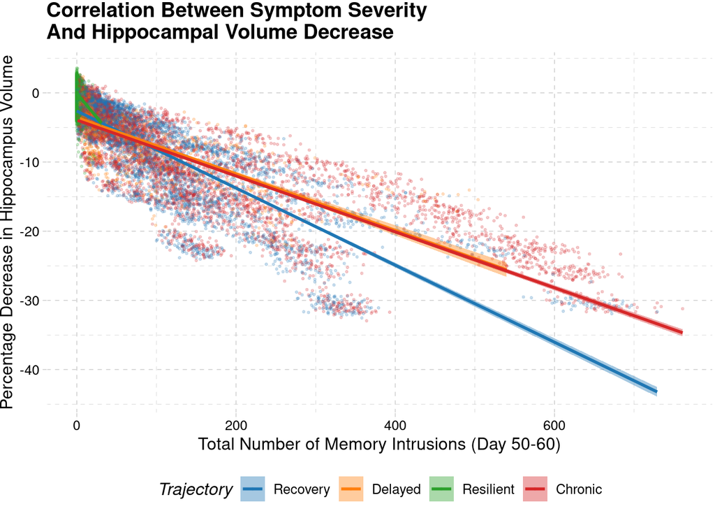

```r
ggplot(filter(hsize_trajectory, I != 1),
       aes(x=CTraumatic, y=HippocampusDecrease, col = Trajectory)) +
  geom_point(alpha = .2, size=0.5) +
  #geom_density_2d() +
  scale_color_d3() +
  #scale_color_brewer(palette="Dark2") +
  #scale_color_viridis(discrete=T, option="inferno", end=0.8) +
  #stat_summary(fun.data = mean_se, geom="point", size=1) +
  #geom_smooth(method = "lm", formula = y ~ x, aes(col=as.factor(I)), fill="white",
  #            fullrange= T) + # theme_pander() +
  geom_smooth(method = "lm", aes(fill=Trajectory),
              se=T, line_style="dashed") +
  scale_fill_d3() +
  ylab("Percentage Decrease in Hippocampus Volume") +
  xlab("Total Number of Memory Intrusions (Day 50-60)") +
  ggtitle("Correlation Between Symptom Severity\nAnd Hippocampal Volume Decrease") +
  theme_pander() +
  theme(legend.position = "bottom") #+
```

```r
hsize_trajectory$Group = "PTSD"
hsize_trajectory$Group[hsize_trajectory$Trajectory == "Resilient"] <- "Control"

hpc_group <- hsize_trajectory %>%
  group_by(Group, Trajectory) %>%
  summarise(VolumeChange = mean(HippocampusDecrease),
            SD = sd(HippocampusDecrease)) %>%
  add_column(region = "parahippocampal")
```

```r
hpc_group$Trajectory <- as.character(hpc_group$Trajectory)

p1 <- hpc_group %>%
  group_by(Group, Trajectory) %>%
  ggplot(aes(fill = VolumeChange)) +
  geom_brain(atlas = dk,
             col="white",
             show.legend = T) +
  coord_sf(xlim = c(750, 1050)) +
  facet_wrap(~ Group + Trajectory,
             ncol=4,
             labeller = label_bquote(
               rows =  .(Group)~( .(Trajectory)))) +
  scale_fill_viridis("Mean %\nVolume Change",
                     option = "plasma",
                     na.value="lightgrey",
                     direction = 1,
                     limits=c(-10.0, 0)
                     ) +
  theme_brain2(text.family = "sans",
               text.colour="black") +
  theme(strip.background = element_blank(),
        strip.text = element_text(size=10, face="bold"),
        legend.position = "right",
        legend.title = element_text(size=10))

p2 <- ggplot(hsize_trajectory,
             aes(x = "",
                 y = HippocampusDecrease)) +
  geom_violin(aes(fill=Group), alpha=0.5,
              col="white", width=1.05, bw=2) +
  scale_fill_npg() +
  stat_summary(geom="point", fun.data="mean_sdl") +
  facet_wrap(~ Group + Trajectory, ncol=4) +

  stat_summary(geom="errorbar", fun.data="mean_sdl", width=.1,
               fun.args = list(mult=1)) +
  ylab("% Volume Change") +
  xlab("") +
  theme_minimal() +
  theme(strip.text=element_blank())

#p1 / p2

#ggsave("figures/figure15.png", dpi=300)
```

### Comparisons

Let’s look at some raw data

```r
hsize_trajectory %>%
  group_by(Group) %>%
  summarise(VolumeChange = mean(HippocampusDecrease),
            SD = sd(HippocampusDecrease)) %>%
  xtable() %>%
  kable() %>%
  kable_styling(bootstrap_options=c("striped", "hover"))
```

| Group | VolumeChange | SD |
| --- | --- | --- |
| Control | -0.2626291 | 1.688191 |
| PTSD | -9.0538188 | 7.771086 |

As expected, the the difference between simulated control groups (Traumatized controls and Traumatized PTSD) is significant to a two-sided, unequal variance *t*-test.

```r
t.test(HippocampusDecrease ~ Group,
       hsize_trajectory,
       var.equal=F) %>%
  tidy() %>%
  kable() %>%
  kable_styling(bootstrap_options = c("striped", "hover"))
```

| estimate | estimate1 | estimate2 | statistic | p.value | parameter | conf.low | conf.high | method | alternative |
| --- | --- | --- | --- | --- | --- | --- | --- | --- | --- |
| 8.79119 | -0.2626291 | -9.053819 | 110.8244 | 0 | 12754.24 | 8.6357 | 8.946679 | Welch Two Sample t-test | two.sided |

Also, the the Control group shows a decrease of hippocampal volume that is small but significantly different than zero:

```r
t.test(filter(hsize_trajectory, Group == "Control")$HippocampusDecrease,
       mean = 0) %>%
  tidy() %>%
  kable() %>%
  kable_styling(bootstrap_options = c("striped", "hover"))
```

| estimate | statistic | p.value | parameter | conf.low | conf.high | method | alternative |
| --- | --- | --- | --- | --- | --- | --- | --- |
| -0.2626291 | -10.53394 | 0 | 4584 | -0.3115072 | -0.2137509 | One Sample t-test | two.sided |

Finally, in the PTSD group, there is a significant difference by trajectories.

```r
traumatized_group_hsize <- hsize_trajectory %>%
  filter(Group == "PTSD")

traumatized_group_hsize %>%
  aov(HippocampusDecrease ~ Trajectory, .)%>%
  summary() %>%
  xtable() %>%
  kable() %>%
  kable_styling(bootstrap_options = c("striped", "hover"))
```

|  | Df | Sum Sq | Mean Sq | F value | Pr(>F) |
| --- | --- | --- | --- | --- | --- |
| Trajectory | 2 | 13121.93 | 6560.96562 | 110.886 | 0 |
| Residuals | 10646 | 629908.36 | 59.16855 | NA | NA |

A pairwise comparison indicates which trajectories are different:

```r
pairwise.t.test(traumatized_group_hsize$HippocampusDecrease,
                traumatized_group_hsize$Trajectory,
                p.adjust.method = "bonferroni", paired=F, pool.sd = F) %>%
  tidy() %>%
  kable() %>%
  kable_styling(bootstrap_options = c("stiped", "hover"))
```

| group1 | group2 | p.value |
| --- | --- | --- |
| Delayed | Recovery | 0 |
| Chronic | Recovery | 0 |
| Chronic | Delayed | 0 |

## Functional Connectivity

Functional conectivity is measured through the similarity between each retrieved chunk and the current context, which is recorded in the `ChunkSimilarity` variable.

We can quickly visualize the effects of different trajectories on connectivity.

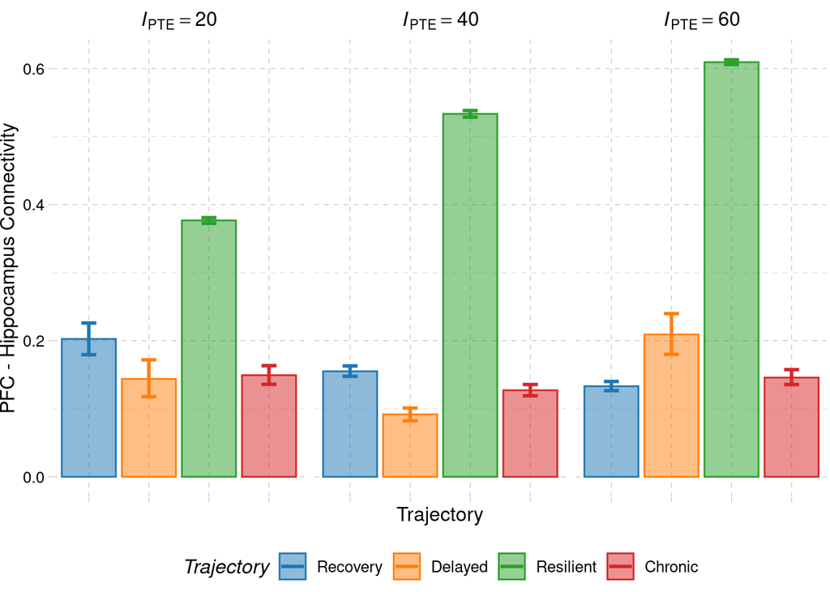

```r
k <- a %>%
  filter(! is.na(ChunkSimilarity),
         C == 0,
         Day > 50)

ggplot(filter(k, I > 1),
       aes(x=Trajectory, y = ChunkSimilarity,
           col=Trajectory, fill=Trajectory)) +
  stat_summary(fun.data=mean_se, geom="bar", alpha=0.5) +
  stat_summary(fun.data=mean_cl_boot, geom="errorbar", width=0.25, size=1) +
  facet_wrap(~I, ncol=3,
             labeller  = label_bquote(
               rows = italic(I)[PTE] == .(I))) +
  ylab("PFC - Hippocampus Connectivity") +
  scale_color_d3() +
  scale_fill_d3() +
  theme_pander() +
  theme(axis.text.x = element_blank(),
        legend.position = "bottom")
```

```r
aconn <- a %>%
  filter(! is.na(ChunkSimilarity),
         C == 0,
         I > 1,
         Day > 50)

aconn$Trajectory <- as.character(aconn$Trajectory)

aconn$Group <- "PTSD"
aconn$Group[aconn$Trajectory == "Resilient"] <- "Control"

conn_group <- aconn %>%
  group_by(Group, Trajectory) %>%
  summarise(FC = mean(ChunkSimilarity),
            SD = sd(ChunkSimilarity))
```

```r
conn1 <- conn_group %>%
  add_column(region = "parahippocampal")

conn2 <- conn_group %>%
  add_column(region = "medial orbitofrontal")

conn_group <- rbind(conn1, conn2)

p1 <- conn_group %>%
  group_by(Group, Trajectory) %>%
  ggplot(aes(fill = FC)) +
  geom_brain(atlas = dk,
             col="white",
             show.legend = T) +
  coord_sf(xlim = c(750, 1050)) +
  facet_wrap(~ Group + Trajectory,
             ncol=4,
             labeller = label_bquote(
               rows =  .(Group)~( .(Trajectory)))) +
  scale_fill_viridis("Mean Functional\nConnectivity",
                     option = "plasma",
                     na.value="lightgrey",
                     direction = 1,
                     limits=c(0.0, 0.5)
                     ) +
  theme_brain2(text.family = "sans",
               text.colour="black") +
  theme(strip.background = element_blank(),
        strip.text = element_text(size=10, face="bold"),
        legend.position = "right",
        legend.title = element_text(size=10))

p2 <- ggplot(aconn,
             aes(x = "",
                 y = ChunkSimilarity)) +
  geom_violin(aes(fill=Group), alpha=0.5,
              col="white", width=1.05,
              bw=0.075) +
  scale_fill_npg() +
  stat_summary(geom="point", fun.data="mean_sdl") +
  stat_summary(geom="errorbar", fun.data="mean_sdl", width=.1,
               fun.args = list(mult=1)) +
  facet_wrap(~ Group + Trajectory, ncol=4) +
  ylab("Functional Connectivity") +
  xlab("") +
  theme_minimal() +
  theme(strip.text=element_blank())

# Multi-plot
#p1 / p2

ggsave("figures/figure16.png", dpi=300)
```

### Comparisons

Let’s look at the raw data and some descriptive statistics about predicted functional connectivity:

```r
conn_group %>%
  filter(region == "parahippocampal") %>%
  dplyr::select(Group, Trajectory, FC, SD) %>%
  xtable() %>%
  kable() %>%
  kable_styling(bootstrap_options=c("striped", "hover"))
```

| Group | Trajectory | FC | SD |
| --- | --- | --- | --- |
| Control | Resilient | 0.4696456 | 0.2361862 |
| PTSD | Chronic | 0.1381222 | 0.1583700 |
| PTSD | Delayed | 0.1253881 | 0.1424886 |
| PTSD | Recovery | 0.1451220 | 0.1522736 |

As expected, the the difference between simulated control groups (Traumatized controls and Traumatized PTSD) is significant to a two-sided, unequal variance *t*-test.

```r
t.test(ChunkSimilarity ~ Group,
       aconn,
       var.equal=F) %>%
  tidy() %>%
  kable() %>%
  kable_styling(bootstrap_options = c("striped", "hover"))
```

| estimate | estimate1 | estimate2 | statistic | p.value | parameter | conf.low | conf.high | method | alternative |
| --- | --- | --- | --- | --- | --- | --- | --- | --- | --- |
| 0.3290981 | 0.4696456 | 0.1405475 | 138.1598 | 0 | 17514.86 | 0.3244291 | 0.3337671 | Welch Two Sample t-test | two.sided |

```r
traumatized_group_aconn <- aconn %>%
  filter(Group != "Control")

traumatized_group_aconn %>%
  aov(ChunkSimilarity ~ Trajectory, .) %>%
  summary() %>%
  xtable() %>%
  kable() %>%
  kable_styling(bootstrap_options=c("striped", "hover"))
```

|  | Df | Sum Sq | Mean Sq | F value | Pr(>F) |
| --- | --- | --- | --- | --- | --- |
| Trajectory | 2 | 0.2654311 | 0.1327155 | 5.635889 | 0.0035837 |
| Residuals | 7002 | 164.8851241 | 0.0235483 | NA | NA |

And the pairwise comparisons:

```r
pairwise.t.test(traumatized_group_aconn$ChunkSimilarity,
                traumatized_group_aconn$Trajectory,
                p.adjust.method = "bonferroni", paired=F, pool.sd = F) %>%
  tidy() %>%
  kable() %>%
  kable_styling(bootstrap_options = c("striped", "hover"))
```

| group1 | group2 | p.value |
| --- | --- | --- |
| Delayed | Chronic | 0.1119543 |
| Recovery | Chronic | 0.2482275 |
| Recovery | Delayed | 0.0019504 |